# ST635 Final Project

Group Echo: Sujith Xavier Kurian, Si Qi Xiao, Joshua Zhang

# Introduction

The National Hockey League (NHL) is one of the four major leagues of sports in North America. Among the four, the NHL is often referred to as the one with the most parity. The parity is achieved through multiple checks and balances. Every NHL team must operate under a standardized budget, they have access to the same pool of players, and the nature of the sport minimizes the direct control any individual player has on the game. One integral part of gaining a competitive advantage in a league ripe with parity is through an annual event called the NHL Draft. The draft allows teams to acquire players in the hopes that the player will contribute a positive impact for the team that drafted them.

We need to clarify what it means to be an impactful player. A player may contribute to the success of a team by scoring, but also by physically intimidating the other team, creating scoring chances, and being involved with the flow of the game. Therefore, we will focus primarily on Action Events, a subjective statistic that combines all the above mentioned contributions into one number.

Summarizing the drafting history across the entire league since 2005, only 22.68% of all drafted players play in the NHL and score at least 10 points. There are also too many draft candidates for any one team to scout with any level of significance. These motivations justify the necessity of having a model that can determine who is an impactful player.

```r
library(dplyr)
library(readxl)
library(tree)
library(boot)
library(pls)
library(readxl)
library(tree)
require(pls)
par(mfrow = c(1, 1))
hockey <- read_excel("ST635 Hockey Data.xlsx")
# hockey <- read_excel("Data/hockey.xlsx")
```

# Data Description

Player Information: Player Name, Team, Country, Height, Weight, DraftAge, Position, Handedness, Overall

Before Draft: GP_1, PRE_G_82, PRE_A_82, PRE_PIM_82, League_1

After Draft: isStarPlayer, NHL_Hits_82, NHL_G_82, NHL_A_82, NHL_P_82, NHL_PIM_82, NHL_S_82, PM, aggPM, catPM, AE, Top33, aggHits, NHL_GP, aggShots

We designated AE to be our response variable. AE stands for Action Events, which is a subjective response variable we created to fairly compare both forwards and defenseman. Other candidates for response included NHL_P_82 and catPM. We did not use NHL_P_82, which stands for 82-game standardized points scored in the NHL, because there is a bias in favor of forwards and against defenseman. The purpose of a forward is to score points, so naturally forwards, even poor forwards, score many points. Defenseman are trained to prevent goals, so scoring points is not a priority for them, which results in a stunted ability to score points. The weakness with catPM, which is a binary classification of whether or not a player has a plus rating or minus rating, which is calculated by how many times they are on the playing surface at the time of their team scoring minus the number of times they are on the playing surface at the time of their team being scored on, is that the metric is heavily influenced by how good a team is. It is a better metric to evaluate a team rather than evaluating an individual.

Now that we have justified the use of AE as our response variable, we do some data cleaning. First we check for outliers.

```r
q1 = quantile(hockey$AE, 0.25)
q3 = quantile(hockey$AE, 0.75)
IQR = q3-q1
high <- q3+1.5*IQR
low <- q1-1.5*IQR
hockey$`Player Name`[hockey$AE>high]
```

```
## [1] "Alex Ovechkin" "Brady Tkachuk" "Evander Kane"  "Dustin Brown"
## [5] "Brandan Guhle"
```

```r
hockey$`Player Name`[hockey$AE<low]
```

```
## [1] "Zachary Werenski" "David Gustafsson" "Nicholas Paul"
```

The output shows us that there are 8 players total that are considered outliers. However, due to our small number of observations in the dataset, we chose to keep the outliers because the values are not unreasonable given the scope of the value of AE for these players.

Next, we decided to check on the variance in the response variable, to see if it is necessary to exert a logistical transformation.

```r
a <- mean(hockey$AE)
b <- sqrt(var(hockey$AE))
a/b
```

```
## [1] 3.3758
```

We felt that this ratio was too small, which signified that the variation was relatively large for this variable, so we applied a log transformation, which will be reflected in the analysis below.

We wanted to analyze two cases for this dataset. First, we wanted to create an overall model that tries to model players blind of the position that they play in. Separately, we want to analyze forwards and defenseman to see if models might differ. We are aware of the fact that doing this separation will cause our n to decrease, but as we still have more than 10:1 ratio of observations to relevant variables, we think it is OK to make this separation.

```r
## Creating training and testing data set for all players
set.seed(100)
sampleIndex <- sample(1:nrow(hockey), 0.75*nrow(hockey))
hockey.train <- hockey[sampleIndex,]
hockey.test <- hockey[-sampleIndex,]

## Forwards are generally coveted for their production, either through goals or assists.
forwards <- hockey[hockey$Position == "F",]
## Defensemen are generally coveted for their prevention of goals, which can be proxied by Plus/Minus.
defense <- hockey[hockey$Position == "D",]

## Creating training and testing data set for forwards.
set.seed(100)
sampleIndex <- sample(1:nrow(forwards), 0.75*nrow(forwards))
forwards.train <- forwards[sampleIndex,]
forwards.test <- forwards[-sampleIndex,]

## Creating training and testing data set for defense.
set.seed(100)
sampleIndex <- sample(1:nrow(defense), 0.75*nrow(defense))
defense.train <- defense[sampleIndex,]
defense.test <- defense[-sampleIndex,]
```

For each of our datasets, we used a ratio of 3:1 training to test. We have now successfully set up our dataset for modeling analysis.

# Exploratory Analysis

## PCA

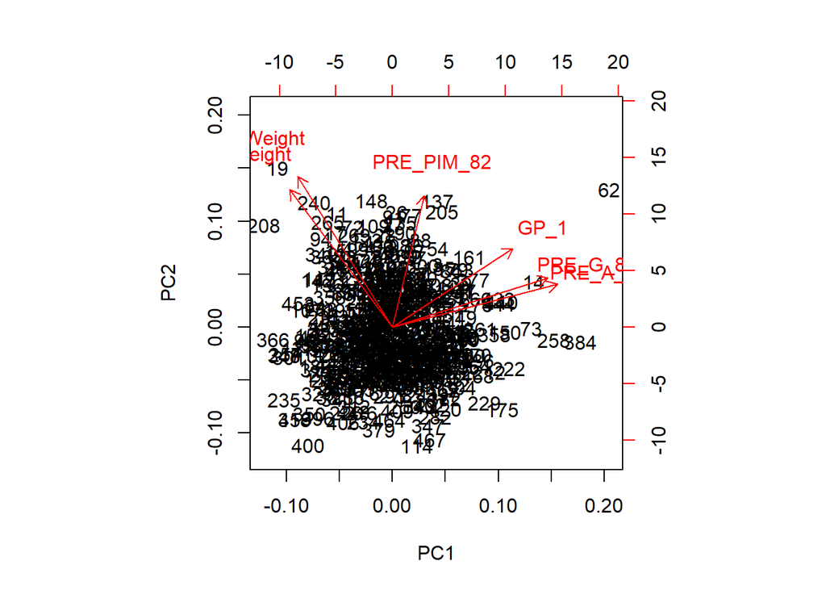

```r
pr.out <- prcomp(hockey[,c(5, 6,10,11,12,13)], scale = TRUE)
biplot(pr.out)
```

```r
# Create PVE plots
(pve <- pr.out$sdev^2/sum(pr.out$sdev^2))
```

```
## [1] 0.37489676 0.30010842 0.13731948 0.09749054 0.04749199 0.04269280
```

```r
cumsum(pve)
```

```
## [1] 0.3748968 0.6750052 0.8123247 0.9098152 0.9573072 1.0000000
```

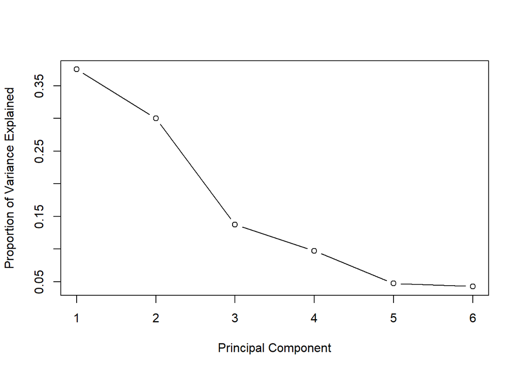

```r
# Plot PVE
# par(mfrow = c(1, 2))
plot(pve, xlab = "Principal Component", ylab = "Proportion of Variance Explained", type = 'b')
```

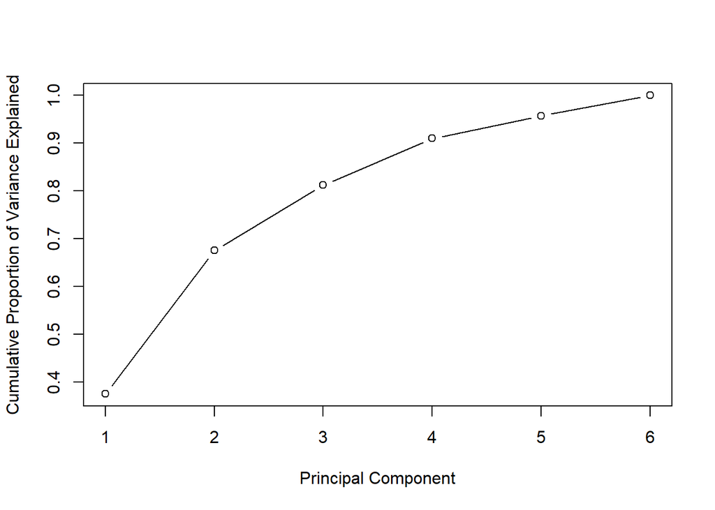

```r
plot(cumsum(pve), xlab = "Principal Component", ylab = "Cumulative Proportion of Variance Explained", type = 'b')
```

```r
# Optimal PC = 4
```

We applied PCA to the whole dataset to determine our ability to reduce the number of variables we need to analyze the dataset. Based on the biplot, we can see four distinct principal components. We confirmed this by looking at the percent of variance explained by the various number of principal components, and decided that the number of principal components we need to use for future analysis is 4.

## k-means Clustering

In order to cluster our data, we decided to utilize our PCA analysis. Given the number of principal components we should use as 4…

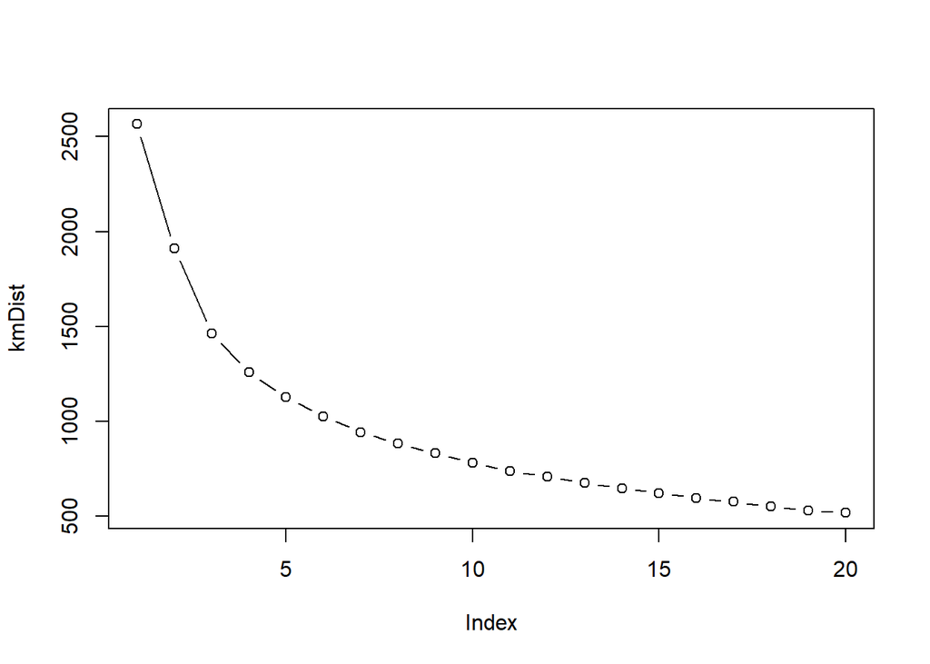

```r
# With pr.out with PC = 4
x <- pr.out$x[,1:4]

kmDist <- rep(0, 20)
for (i in 1:20){
  hockey.km <- kmeans(x, centers = i, iter.max = 50, nstart = 50)
  kmDist[i] <- hockey.km$tot.withinss
}

par(mfrow = c(1, 1))
plot(kmDist, type = 'b')
```

We find out that the elbow point, which we use to select a good number of clusters, resides at 3. Using this information, we cluster our dataset.

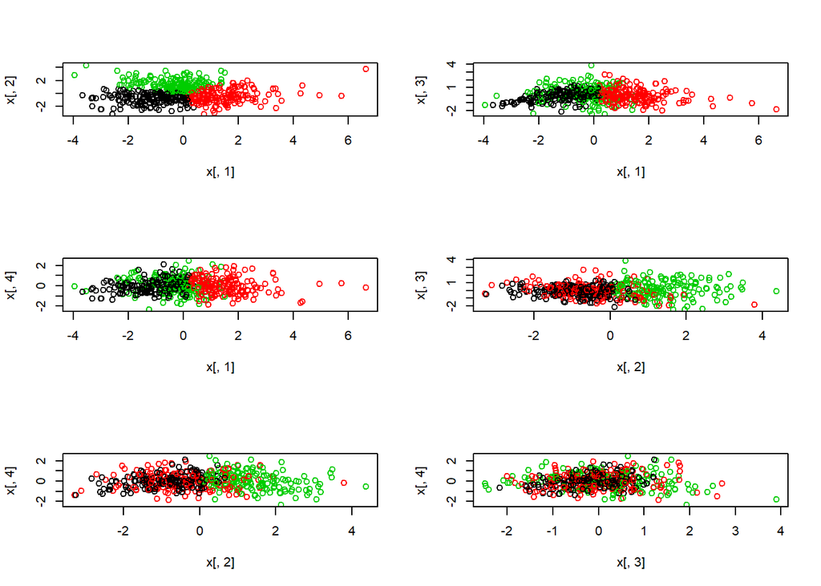

```r
hockey.km <- kmeans(x, centers = 3, iter.max = 50, nstart = 50)
par(mfrow = c(3, 2))
plot(x[,1], x[,2], col = hockey.km$cluster)
plot(x[,1], x[,3], col = hockey.km$cluster)
plot(x[,1], x[,4], col = hockey.km$cluster)
plot(x[,2], x[,3], col = hockey.km$cluster)
plot(x[,2], x[,4], col = hockey.km$cluster)
plot(x[,3], x[,4], col = hockey.km$cluster)
```

We can clearly interpret the clustering around our first two principal components. To refresh, PC1 describes on-ice performance, with positive values representing high amounts of goal scoring and assisting. PC2 describes physical metrics, such as height and weight. Our three groups are separated as physically gifted players who have an average scoring ability, average to below average physically gifted players who do not score many points, and average to below average physically gifted players who score many points. It seems that the other principal components, which involve how many penalty minutes they accrue, along with games played before being drafted do not distinguish scoring ability or body type.

# Modeling

Our group wanted to create models which can expose some relationships between the predictors and the response, log(AE). Below, we will use linear regression, regression trees, and PCR.

## Linear Regression - Full Dataset

Our first model is to use linear regression on the whole data set, using the logarithmically transformed AE as the response. We use stepwise variable selection immediately.

```r
# Linear Regression
empty.model <- glm(log(AE) ~ 1, data = hockey.train)
full.model <- glm(log(AE) ~ Country + Height + Weight + Position + Handedness + GP_1 + PRE_G_82 + PRE_A_82 + PRE_PIM_82 + League_1, data = hockey.train)

# Stepwise variable selection
model.backwards <- step(full.model, scope = list(lower = empty.model$formula, upper = full.model$formula), direction = 'backward', k = 2, trace = 0)
attr(model.backwards$terms,"variables")
```

```
## list(log(AE), Weight, Handedness, GP_1, PRE_G_82, PRE_PIM_82,
##     League_1)
```

```r
model.forwards <- step(empty.model, scope = list(lower = empty.model$formula, upper = full.model$formula), direction = 'forward', k = 2, trace = 0)
attr(model.forwards$terms,"variables")
```

```
## list(log(AE), PRE_PIM_82, League_1, PRE_G_82, Weight, Handedness,
##     GP_1)
```

The stepwise variable selection gave us identical results, so we do not need to test each one to see which model performs better. Now we can create the linear regression model.

```r
reg <- lm(log(AE) ~ Weight + Position + Handedness + GP_1 + PRE_G_82 + PRE_PIM_82, data = hockey.train)
summary(reg)
```

```
##
## Call:
## lm(formula = log(AE) ~ Weight + Position + Handedness + GP_1 +
##     PRE_G_82 + PRE_PIM_82, data = hockey.train)
##
## Residuals:
##      Min       1Q   Median       3Q      Max
## -2.28006 -0.14901  0.04659  0.17458  0.85669
##
## Coefficients:
##               Estimate Std. Error t value Pr(>|t|)
## (Intercept)  4.6797307  0.2350335  19.911  < 2e-16 ***
## Weight       0.0038544  0.0011141   3.459 0.000609 ***
## PositionF    0.0686295  0.0434531   1.579 0.115159
## HandednessR  0.0854851  0.0337544   2.533 0.011765 *
## GP_1        -0.0019289  0.0010791  -1.788 0.074727 .
## PRE_G_82     0.0023918  0.0008340   2.868 0.004389 **
## PRE_PIM_82   0.0015712  0.0002895   5.427 1.08e-07 ***
## ---
## Signif. codes:  0 '***' 0.001 '**' 0.01 '*' 0.05 '.' 0.1 ' ' 1
##
## Residual standard error: 0.3016 on 346 degrees of freedom
## Multiple R-squared:  0.2281, Adjusted R-squared:  0.2147
## F-statistic: 17.04 on 6 and 346 DF,  p-value: < 2.2e-16
```

Since stepwise variable selection was run, we will not evaluate the regression model via p-value, as their significance is trivialized. However, we need to find a metric that can be used to compare this model to others, which is the Test MSE.

```r
hockey.pred<- predict(reg ,hockey.test)
sqrt(mean((hockey.test$AE - hockey.pred) ^ 2))
```

```
## [1] 307.9919
```

The testing set MSE is approximately 308. the adjusted R-squared is 0.2147.

Next step is to check the linear regression residual assumptions.

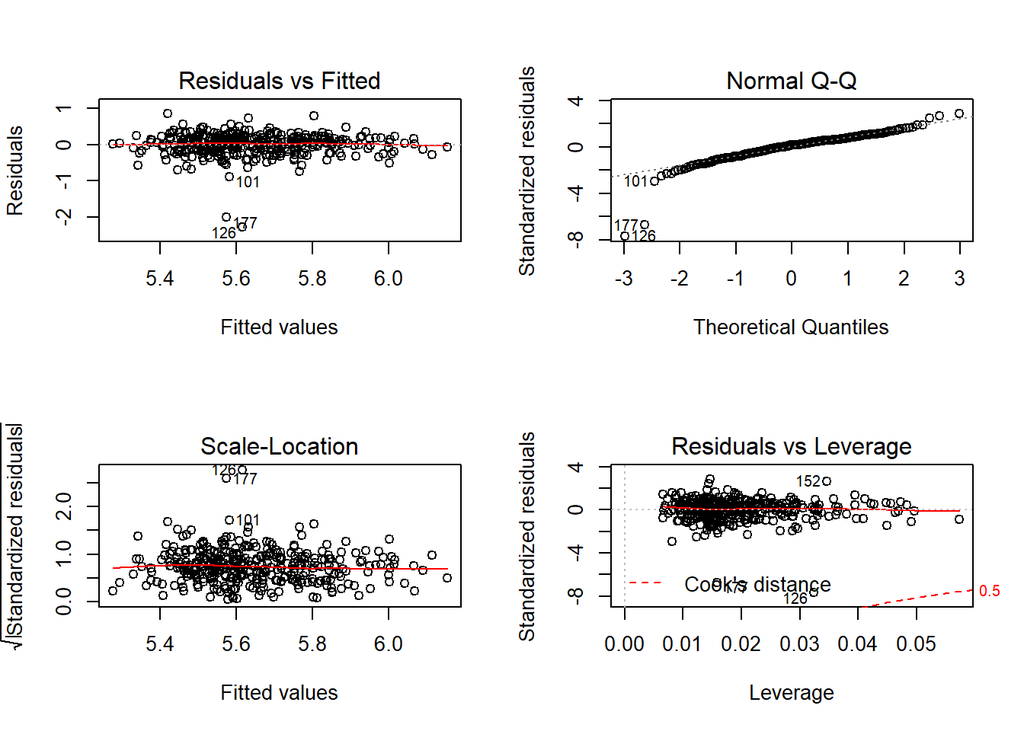

```r
par(mfrow = c(2, 2))
plot(reg)
```

In our opinion, the residuals all check out fine and we accept the use of the linear regression above.

This analysis is repeated for the forwards and defense datasets. Our results and interpretation mirror those of the full dataset, so we will not comment on the individual findings, but we will summarize at the end of the linear regression analysis.

## Linear Regression - Forwards Dataset

```r
empty.model <- glm(log(AE) ~ 1, data = forwards.train)
full.model <- glm(log(AE) ~ Country + Height + Weight + Handedness + GP_1 + PRE_G_82 + PRE_A_82 + PRE_PIM_82 + League_1, data = forwards.train)

model.backwards <- step(full.model, scope = list(lower = empty.model$formula, upper = full.model$formula), direction = 'backward', k = 2, trace = 0)
attr(model.backwards$terms,"variables")
```

```
## list(log(AE), Height, Weight, Handedness, GP_1, PRE_G_82, PRE_PIM_82)
```

```r
model.forwards <- step(empty.model, scope = list(lower = empty.model$formula, upper = full.model$formula), direction = 'forward', k = 2, trace = 0)
attr(model.forwards$terms,"variables")
```

```
## list(log(AE), PRE_PIM_82, Weight, PRE_G_82, GP_1, Handedness,
##     Height)
```

```r
# Based on the stepwise variable selection above, we now run regressions.
reg3 <- lm(log(AE) ~Weight + Handedness + GP_1 + PRE_G_82 + PRE_PIM_82, data = forwards.train)
summary(reg3)
```

```
##
## Call:
## lm(formula = log(AE) ~ Weight + Handedness + GP_1 + PRE_G_82 +
##     PRE_PIM_82, data = forwards.train)
##
## Residuals:
##     Min      1Q  Median      3Q     Max
## -2.2472 -0.1410  0.0525  0.1719  0.8218
##
## Coefficients:
##               Estimate Std. Error t value Pr(>|t|)
## (Intercept)  4.9044646  0.2748005  17.847  < 2e-16 ***
## Weight       0.0034062  0.0013386   2.545  0.01161 *
## HandednessR  0.0761415  0.0429549   1.773  0.07765 .
## GP_1        -0.0033856  0.0013723  -2.467  0.01437 *
## PRE_G_82     0.0024516  0.0008898   2.755  0.00634 **
## PRE_PIM_82   0.0018167  0.0003568   5.092 7.49e-07 ***
## ---
## Signif. codes:  0 '***' 0.001 '**' 0.01 '*' 0.05 '.' 0.1 ' ' 1
##
## Residual standard error: 0.3058 on 225 degrees of freedom
## Multiple R-squared:  0.2097, Adjusted R-squared:  0.1921
## F-statistic: 11.94 on 5 and 225 DF,  p-value: 2.92e-10
```

```r
# Based on the results of the two models, reg3a seems to be better in both error and adj-R2.

#predict in testing error
(forwards.pred<- predict(reg3,forwards.test))
```

```
##        1        2        3        4        5        6        7        8
## 6.083177 6.042676 5.581143 5.753239 6.092875 6.188185 5.628801 5.825020
##        9       10       11       12       13       14       15       16
## 6.021975 5.725203 5.667017 5.654886 5.835269 5.958310 5.724838 5.816625
##       17       18       19       20       21       22       23       24
## 5.742053 5.599011 5.677885 6.019468 5.854105 5.626344 5.596772 5.940434
##       25       26       27       28       29       30       31       32
## 5.829388 5.672251 5.757701 5.581625 5.634170 5.968356 5.443044 5.570471
##       33       34       35       36       37       38       39       40
## 5.744149 5.629203 5.661508 5.412192 5.463703 5.540045 5.587467 5.674692
##       41       42       43       44       45       46       47       48
## 5.707856 5.513572 5.679750 5.489977 5.543362 5.769328 5.805285 5.457062
##       49       50       51       52       53       54       55       56
## 5.663658 5.664286 5.698420 5.732991 5.608451 5.862217 5.722083 5.597561
##       57       58       59       60       61       62       63       64
## 5.802749 5.636967 5.551846 5.795708 6.049902 5.736608 5.691966 5.650617
##       65       66       67       68       69       70       71       72
## 5.653134 5.446879 5.720342 5.588076 5.631082 5.448264 5.532592 5.773940
##       73       74       75       76       77       78
## 5.604145 5.557900 5.577424 5.459865 5.606145 5.553938
```

```r
sqrt(mean((forwards.test$AE - forwards.pred) ^ 2))
```

```
## [1] 315.905
```

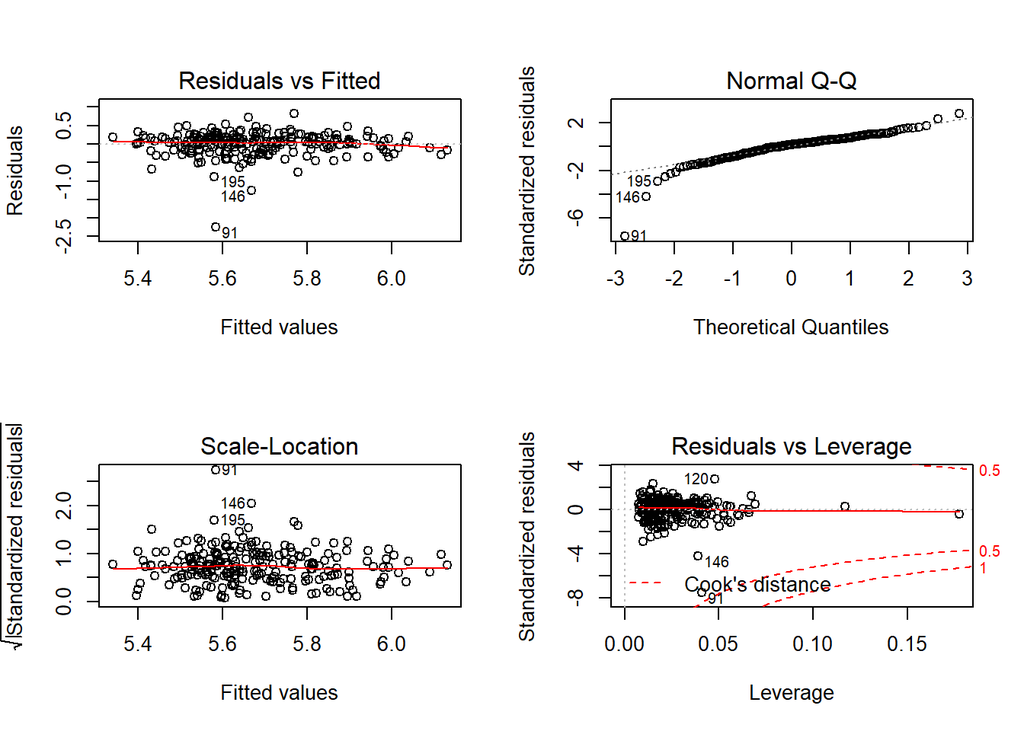

```r
# Checking linear regression residual assumptions
par(mfrow = c(2, 2))
plot(reg3)
```

The testing set MSE is approximately 316. The adjusted R-squared is 0.1921.

Finally, we will look at the results for the defense dataset.

## Linear Regression - Defense Dataset

```r
empty.model <- glm(log(AE) ~ 1, data = defense.train)
full.model <- glm(log(AE) ~ Country + Height + Weight + Handedness + GP_1 + PRE_G_82 + PRE_A_82 + PRE_PIM_82 + League_1, data = defense.train)

model.backwards <- step(full.model, scope = list(lower = empty.model$formula, upper = full.model$formula), direction = 'backward', k = 2, trace = 0)
attr(model.backwards$terms,"variables")
```

```
## list(log(AE), Weight, Handedness, PRE_A_82, PRE_PIM_82)
```

```r
model.forwards <- step(empty.model, scope = list(lower = empty.model$formula, upper = full.model$formula), direction = 'forward', k = 2, trace = 0)
attr(model.forwards$terms,"variables")
```

```
## list(log(AE), PRE_PIM_82, Weight, Handedness, PRE_A_82)
```

```r
# Based on the stepwise variable selection above, we now run regressions.
reg6 <- lm(log(AE) ~  Weight + Handedness + PRE_PIM_82, data = defense.train)
summary(reg6)
```

```
##
## Call:
## lm(formula = log(AE) ~ Weight + Handedness + PRE_PIM_82, data = defense.train)
##
## Residuals:
##      Min       1Q   Median       3Q      Max
## -0.54431 -0.16095  0.01351  0.13126  0.60480
##
## Coefficients:
##              Estimate Std. Error t value Pr(>|t|)
## (Intercept) 4.2125532  0.2832718  14.871  < 2e-16 ***
## Weight      0.0058509  0.0014232   4.111 7.34e-05 ***
## HandednessR 0.1476268  0.0418180   3.530 0.000595 ***
## PRE_PIM_82  0.0012827  0.0003121   4.110 7.36e-05 ***
## ---
## Signif. codes:  0 '***' 0.001 '**' 0.01 '*' 0.05 '.' 0.1 ' ' 1
##
## Residual standard error: 0.2249 on 117 degrees of freedom
## Multiple R-squared:  0.3742, Adjusted R-squared:  0.3582
## F-statistic: 23.32 on 3 and 117 DF,  p-value: 6.63e-12
```

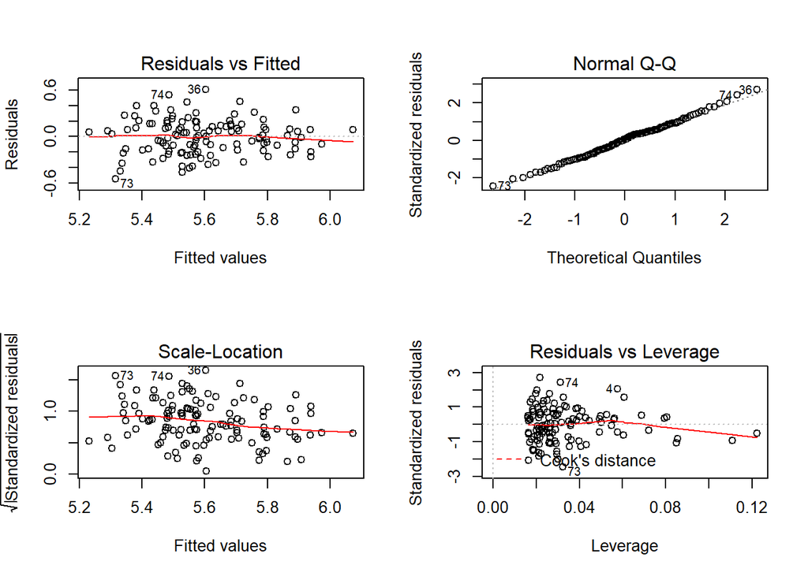

```r
# Checking linear regression residual assumptions
par(mfrow = c(2, 2))
plot(reg6)
```

```r
#MSE for predict in testing

(defense.pred<- predict(reg6,defense.test))
```

```
##        1        2        3        4        5        6        7        8
## 5.445748 5.970692 5.707291 5.737218 5.688123 5.628510 5.790960 5.511131
##        9       10       11       12       13       14       15       16
## 5.790960 5.770738 5.799079 5.482579 5.541228 5.669115 5.509114 5.400988
##       17       18       19       20       21       22       23       24
## 5.556081 5.524910 5.709961 5.582395 5.534243 5.303921 5.685664 5.637462
##       25       26       27       28       29       30       31       32
## 5.554897 5.577408 5.431617 5.532327 5.853433 5.342157 5.462226 5.297749
##       33       34       35       36       37       38       39       40
## 5.628831 5.521458 5.809215 5.312552 5.459527 5.483121 5.320099 5.595442
##       41
## 5.475323
```

```r
sqrt(mean((defense.test$AE - defense.pred) ^ 2))
```

```
## [1] 294.1441
```

The testing set MSE is approximately 294. The adjusted R-squared is 0.3582.

## Regression Tree - Full Dataset

For our analysis on the regression tree, we start by putting in all the relevant predictor variables and letting the regression tree determine the best variables to use.

```r
  hockey.b.tree <- tree(log(AE) ~ Country + Height + Weight + Position + Handedness + GP_1 + PRE_G_82 + PRE_A_82 + PRE_PIM_82 + League_1, data = hockey.train)
  summary(hockey.b.tree)
```

```
##
## Regression tree:
## tree(formula = log(AE) ~ Country + Height + Weight + Position +
##     Handedness + GP_1 + PRE_G_82 + PRE_A_82 + PRE_PIM_82 + League_1,
##     data = hockey.train)
## Variables actually used in tree construction:
## [1] "PRE_PIM_82" "PRE_G_82"   "GP_1"       "Weight"     "PRE_A_82"
## [6] "Height"
## Number of terminal nodes:  11
## Residual mean deviance:  0.08001 = 27.36 / 342
## Distribution of residuals:
##    Min. 1st Qu.  Median    Mean 3rd Qu.    Max.
## -1.4300 -0.1699  0.0152  0.0000  0.1803  1.2550
```

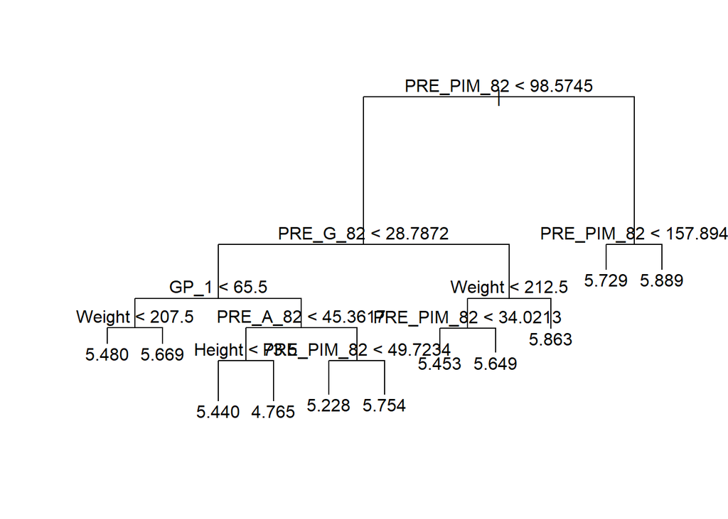

```r
  # Plot un-cut tree
  plot(hockey.b.tree)
  text(hockey.b.tree, pretty = 0)
```

We see the un-cut regression tree is very complex, and an obligatory step is to determine the optimal size of the pruned tree via cross validation, and then plotting the pruned tree.

```r
  set.seed(1)
  cv.hockey.b.tree <- cv.tree(hockey.b.tree, FUN = prune.tree, K = 10)
  cv.hockey.b.tree
```

```
## $size
## [1] 11 10  9  8  7  6  3  2  1
##
## $dev
## [1] 46.39472 46.19451 45.40257 45.36624 43.94246 43.22257 42.55154 38.00468
## [9] 41.01324
##
## $k
## [1]      -Inf 0.4759821 0.7500567 0.7636347 0.9280812 1.0349583 1.0624581
## [8] 1.6722498 4.5851938
##
## $method
## [1] "deviance"
##
## attr(,"class")
## [1] "prune"         "tree.sequence"
```

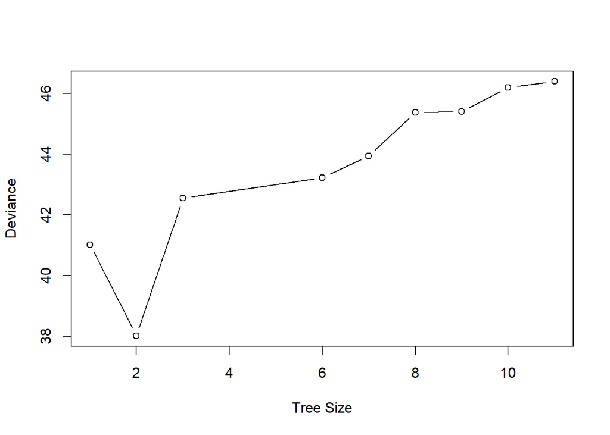

```r
  # Print best tree size
   plot(cv.hockey.b.tree$size, cv.hockey.b.tree$dev, type = 'b', xlab = 'Tree Size', ylab = 'Deviance')
```

```r
  (bestsize <- cv.hockey.b.tree$size[which.min(cv.hockey.b.tree$dev)])
```

```
## [1] 2
```

```r
  # OPS.hockey[i] <- bestsize

  # Based on the distribution of 500 regression trees, the manually determined optimal tree size is 2.
  # bestsize <- 2

  # Optimal size for pruned tree is 2. Prune the tree, Captain!
  prune.hockey.b.tree <- prune.tree(hockey.b.tree, best = bestsize)
  (prune.hockey.b.tree)
```

```
## node), split, n, deviance, yval
##       * denotes terminal node
##
## 1) root 353 40.760 5.644
##   2) PRE_PIM_82 < 98.5745 232 28.260 5.561 *
##   3) PRE_PIM_82 > 98.5745 121  7.916 5.802 *
```

```r
  # Predict using the regression tree and determine the error.
  hockey.b.tree.predict <- predict(prune.hockey.b.tree, newdata = hockey.test)
  sqrt(mean((hockey.b.tree.predict - hockey.test$AE)^2))
```

```
## [1] 308.0036
```

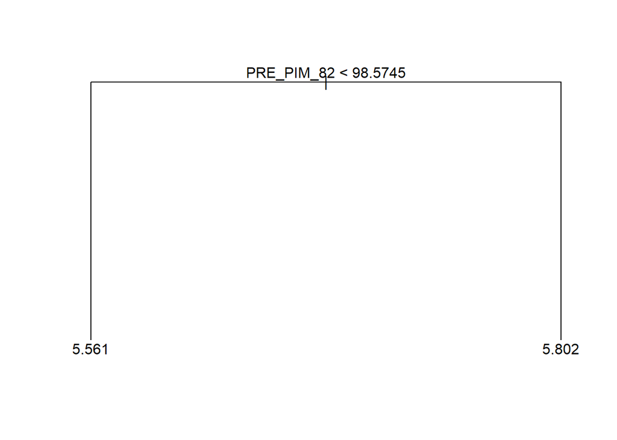

```r
  # Plot cut tree
  plot(prune.hockey.b.tree)
  text(prune.hockey.b.tree, pretty = 0)
```

In our original analysis, we wanted to run the cross validation of the regression tree model to see what the distribution of the best sizes would be. This is because any individual run in determining the best prune size can be highly volatile. In this output, we just set.seed for reproducability and the tree we get is representative of our analysis in general.

We do a very similar process for the forwards and defense datasets.

## Regression Tree - Forwards Dataset

```r
  forwards.c.tree <- tree(log(AE) ~ Country + Height + Weight + Handedness + GP_1 + PRE_G_82 + PRE_A_82 + PRE_PIM_82 + League_1, data = forwards.train)
  summary(forwards.c.tree)
```

```
##
## Regression tree:
## tree(formula = log(AE) ~ Country + Height + Weight + Handedness +
##     GP_1 + PRE_G_82 + PRE_A_82 + PRE_PIM_82 + League_1, data = forwards.train)
## Variables actually used in tree construction:
## [1] "PRE_PIM_82" "PRE_G_82"   "GP_1"       "Weight"     "PRE_A_82"
## Number of terminal nodes:  12
## Residual mean deviance:  0.07355 = 16.11 / 219
## Distribution of residuals:
##     Min.  1st Qu.   Median     Mean  3rd Qu.     Max.
## -1.68400 -0.11360  0.01692  0.00000  0.15090  0.73090
```

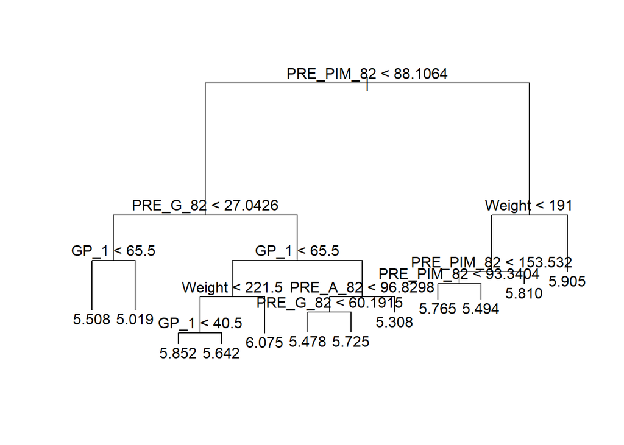

```r
  # Plot un-cut tree
  plot(forwards.c.tree)
  text(forwards.c.tree, pretty = 0)
```

```r
  # Prune the tree
  set.seed(1)
  cv.forwards.c.tree <- cv.tree(forwards.c.tree, FUN = prune.tree, K = 10)
  cv.forwards.c.tree
```

```
## $size
## [1] 12 11  9  7  6  5  3  2  1
##
## $dev
## [1] 30.71101 30.45186 29.70341 29.80209 27.47216 27.47216 28.17884 27.99098
## [9] 27.61451
##
## $k
## [1]      -Inf 0.2681729 0.3370045 0.4296182 0.8815884 0.8941029 1.1598174
## [8] 1.3914567 3.2349658
##
## $method
## [1] "deviance"
##
## attr(,"class")
## [1] "prune"         "tree.sequence"
```

```r
  # Print best tree size
  (bestsize <- cv.forwards.c.tree$size[which.min(cv.forwards.c.tree$dev)])
```

```
## [1] 6
```

```r
  # OPS.forwards[i] <- bestsize

  # Based on the distribution of 500 regression trees, the manually determined optimal tree size is 6.
  #bestsize <- 6

  # Optimal size for pruned tree is 6. Prune the tree, Captain!
  prune.forwards.c.tree <- prune.tree(forwards.c.tree, best = 6)

  # Predict using the regression tree and determine the error.
  forwards.c.tree.predict <- predict(prune.forwards.c.tree, newdata = forwards.test)
  sqrt(mean((forwards.c.tree.predict - forwards.test$AE)^2))
```

```
## [1] 315.9015
```

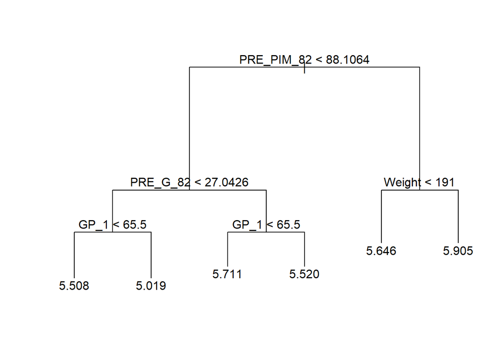

```r
  # Plot cut tree
  plot(prune.forwards.c.tree)
  text(prune.forwards.c.tree, pretty = 0)
```

## Regression Tree - Defense Dataset

```r
  defense.c.tree <- tree(log(AE) ~ Country + Height + Weight + Handedness + GP_1 + PRE_G_82 + PRE_A_82 + PRE_PIM_82 + League_1, data = defense.train)
  summary(defense.c.tree)
```

```
##
## Regression tree:
## tree(formula = log(AE) ~ Country + Height + Weight + Handedness +
##     GP_1 + PRE_G_82 + PRE_A_82 + PRE_PIM_82 + League_1, data = defense.train)
## Variables actually used in tree construction:
## [1] "PRE_PIM_82" "Weight"     "PRE_A_82"   "GP_1"       "Height"
## Number of terminal nodes:  15
## Residual mean deviance:  0.03511 = 3.721 / 106
## Distribution of residuals:
##     Min.  1st Qu.   Median     Mean  3rd Qu.     Max.
## -0.48160 -0.10690 -0.02478  0.00000  0.12520  0.43950
```

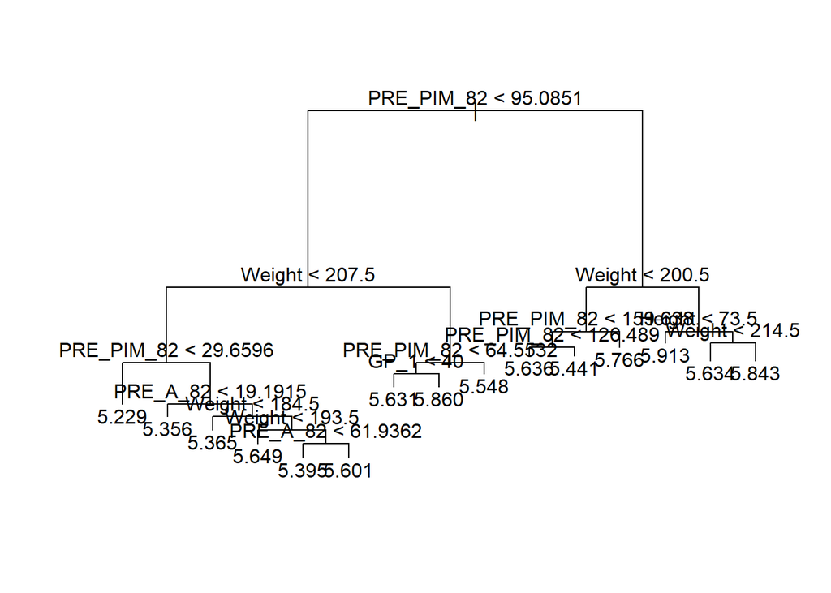

```r
  # Plot un-cut tree
  plot(defense.c.tree)
  text(defense.c.tree, pretty = 0)
```

```r
  # Prune the tree
  set.seed(1)
  cv.defense.c.tree <- cv.tree(defense.c.tree, FUN = prune.tree, K = 10)
  cv.defense.c.tree
```

```
## $size
##  [1] 15 14 12  8  6  5  4  3  2  1
##
## $dev
##  [1]  9.803951  9.978109 10.025752 10.032177  9.584692  9.404469  8.204428
##  [8]  8.160167  8.675711  9.787231
##
## $k
##  [1]      -Inf 0.1032057 0.1471123 0.1649320 0.1774597 0.1924204 0.5073784
##  [8] 0.5404001 0.9209557 2.1635504
##
## $method
## [1] "deviance"
##
## attr(,"class")
## [1] "prune"         "tree.sequence"
```

```r
  # Print best tree size
  (bestsize <- cv.defense.c.tree$size[which.min(cv.defense.c.tree$dev)])
```

```
## [1] 3
```

```r
  # OPS.defense[i] <- bestsize

  # Based on the distribution of 500 regression trees, the manually determined optimal tree size is 2.
  # bestsize <- 3

  # Optimal size for pruned tree is 3. Prune the tree, Captain!
  prune.defense.c.tree <- prune.tree(defense.c.tree, best = bestsize)

  # Predict using the regression tree and determine the error.
  defense.c.tree.predict <- predict(prune.defense.c.tree, newdata = defense.test)
  sqrt(mean((defense.c.tree.predict - defense.test$AE)^2))
```

```
## [1] 294.1018
```

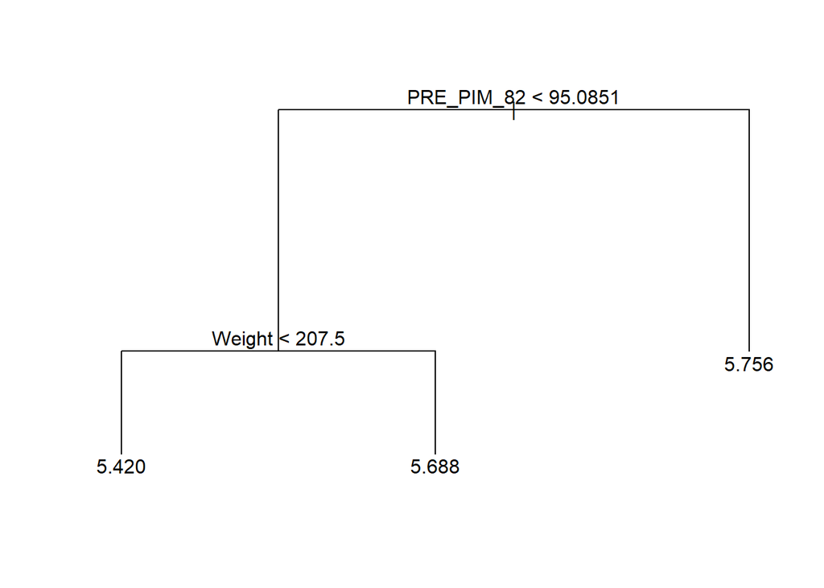

```r
  # Plot cut tree
  plot(prune.defense.c.tree)
  text(prune.defense.c.tree, pretty = 0)
```

This concludes the section on regression tree analysis. We made one more model, which is PCR, which we will discuss next.

## PCR Analysis

We determined that we could model our dataset using PCR, which is executed from the code below.

```r
set.seed(1)
hockey.pcr.fit <- pcr(log(AE) ~ Height + Weight + GP_1 + PRE_G_82 + PRE_A_82 + PRE_PIM_82, data = hockey, scale = TRUE, validation = "CV", segments = 10)
summary(hockey.pcr.fit)
```

```
## Data:    X dimension: 471 6
##  Y dimension: 471 1
## Fit method: svdpc
## Number of components considered: 6
##
## VALIDATION: RMSEP
## Cross-validated using 10 random segments.
##        (Intercept)  1 comps  2 comps  3 comps  4 comps  5 comps  6 comps
## CV          0.3411   0.3411   0.3198   0.3197   0.3088   0.3071   0.3063
## adjCV       0.3411   0.3411   0.3197   0.3196   0.3087   0.3069   0.3061
##
## TRAINING: % variance explained
##          1 comps  2 comps  3 comps  4 comps  5 comps  6 comps
## X        37.4897    67.50    81.23    90.98    95.73   100.00
## log(AE)   0.3988    12.86    13.15    19.16    20.48    20.92
```

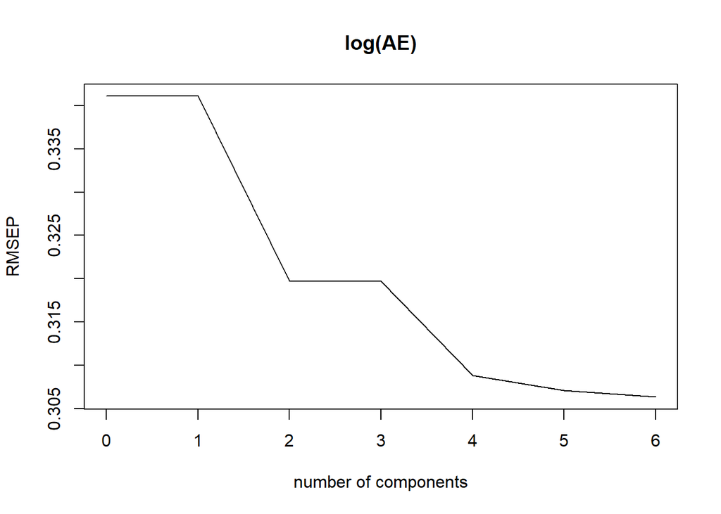

```r
validationplot(hockey.pcr.fit, val.type = 'RMSEP', estimate = "CV")
```

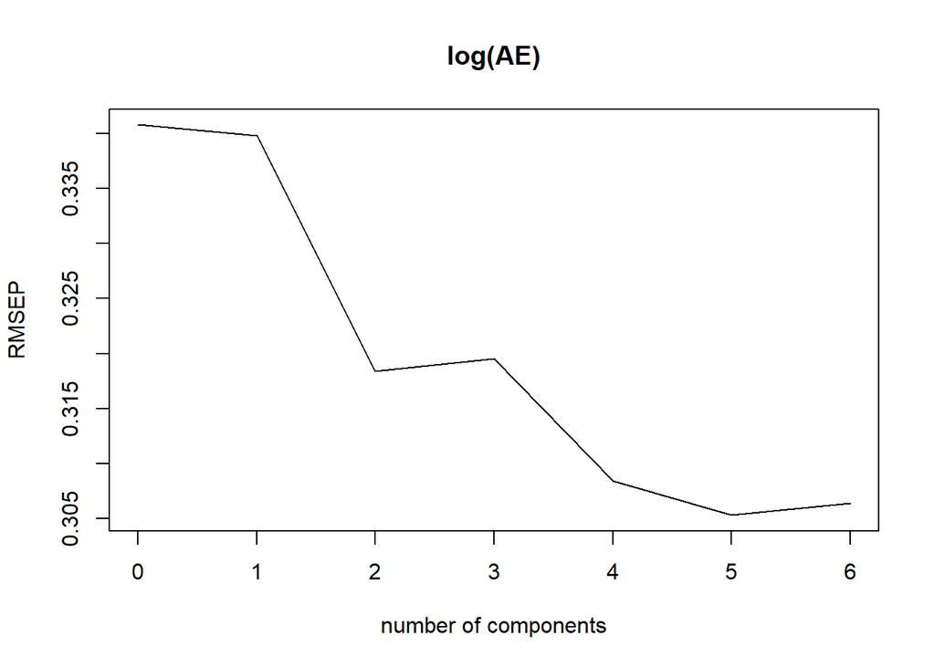

```r
hockey.train.pcr.fit <- pcr(log(AE) ~ Height + Weight + GP_1 + PRE_G_82 + PRE_A_82 + PRE_PIM_82, data = hockey.train, scale = TRUE, validation = "CV", segments = 10)
validationplot(hockey.train.pcr.fit, val.type = 'RMSEP', estimate = "CV")
```

```r
(M <- which.min(hockey.train.pcr.fit$validation$PRESS))
```

```
## [1] 5
```

```r
hockey.train.pcr.pred <- predict(hockey.train.pcr.fit, hockey.test, ncomp = M)
sqrt(mean((hockey.train.pcr.pred - hockey.test$AE)^2))
```

```
## [1] 307.9919
```

```r
hockey.pcr.fit.M <- pcr(log(AE) ~ Height + Weight + GP_1 + PRE_G_82 + PRE_A_82 + PRE_PIM_82, data = hockey, scale = TRUE, validation = "CV", segments = 10, ncomp = M)
summary(hockey.pcr.fit.M)
```

```
## Data:    X dimension: 471 6
##  Y dimension: 471 1
## Fit method: svdpc
## Number of components considered: 5
##
## VALIDATION: RMSEP
## Cross-validated using 10 random segments.
##        (Intercept)  1 comps  2 comps  3 comps  4 comps  5 comps
## CV          0.3411   0.3409   0.3192   0.3189   0.3085   0.3060
## adjCV       0.3411   0.3409   0.3191   0.3188   0.3083   0.3059
##
## TRAINING: % variance explained
##          1 comps  2 comps  3 comps  4 comps  5 comps
## X        37.4897    67.50    81.23    90.98    95.73
## log(AE)   0.3988    12.86    13.15    19.16    20.48
```

Our conclusion is that based on the RMSEP plot, the minimum error is achieved with 5 components. With 5 components, we can explain 20.48% of the variance in log(AE), which is still less robust than the linear regression with the whole dataset. Therefore, our analysis ends for PCR.

# Interpretation

To analyze the data we looked at the overall data which includes Forward and Defense players and then we considered the Forward and Defense players separately. For identifying Activity events score of a player the Forward and Defense players were treated differently because they play a different role in the game. Forward focuses on scoring goals and Defense focuses on preventing the other team from scoring a goal. From the available data the response variable Action Events was defined using a formula which we believe will represent the performance of a hockey player.

We have a Linear regression model and a Tree method model for each of the combined and Forwards / Defense data segments that were considered. The common predictors in all three regression models are Weight, Handedness and Penalty in minutes for a logarithmic response of Action Events.

We also observed that based on the available data the Adjusted R2 value for all the three models are comparatively low and we believe that if we can gather more sample data or more associated variables we will be able to develop a model with a larger R2 value.

From a Regression Tree perspective all three Tree models say that Penalty in Minutes is the most important factor that defines the Action Events on a logarithmic scale.

Regression Tree for Forward - After pruning the tree with a best size of 6 we see that Penalty in minutes is the most important factor, followed by Goals scored, Weight and Games played which defines Action Events on a logarithmic scale.

Regression Tree for Defense - After pruning the tree with a best size of 3 we see that Penalty in minutes is the most important factor followed by Weight for Action Event for Defense on a logarithmic scale.

## Explanation of Coefficients of Linear regression:

The coefficients from the 3 Linear regression models obtained for the Combined data, Forward and Defense data - Weight , Handedness, Goals scored, Penalty in minutes have a positive response to Action Events, whereas Games Played has a negative response. Which says that the Games played is less impactful to Action events.

From a Principal Component Analysis perspective we see that the First Principal Component Analysis which is the best PCA is explained by Goals scored and Assists provided by the players.

## Combined data:

Looking at the testing error for linear regression and tree regression is almost similar. The model does not explain a lot of variance but it explains some of the variance.

# Conclusion

The Parametric and Non-Parametric Statistical Analysis done with both Forward and Defense players together and Forward and Defense separately states that Total Penalty in minutes, Goals scored, Games played and Weight are the key factors that decide the overall performance of a player to be successful in the NHL.

Based on the modeling when considering a draft player the most important factor is Total Penalty in minutes. The Penalty in minutes is one of the key factors that defines how aggressive a player is. However, it is important to have players with a good mix of goals scored, games played and weight. In short, Instead of guessing and relying on the instincts of the scouting teams our recommendation provides the NHL team with a methodical process to select a good draft player who will be successful in the NHL.

# Critique

More Predictors: The overall model performance can be improved by researching and identifying more predictors. Drafted but not in NHL: On the flip side reviewing data of players who got drafted but did not make it to the National Hockey League will provide insights on the contributing factors.

Subjective Response variable: The Action Events variable measure is not an industry standard and was developed and defined to identify a way to measure player’s performance.

Non-Quantitative factors: A strong performing draft player can get impacted by non-quantitative factors like mental health, physical injuries, nutrition etc. This has not been considered in the analysis but should must be researched and included when drafting players for NHL.

# References

● http://www.nhl.com/stats/ ● https://www.hockey-reference.com/ ● http://www.hockeydb.com/

# Variable Explanations

Team: The team the player plays on as of December 1st, 2019.

Player: Name The name of the player.

Overall: The order in which the player was picked in their draft eligible year.

Country: Country of birth.

Height: Height measured in inches.

Weight: Weight measured in pounds.

DraftAge: Years old the player was when draft eligible.

Position: Whether player plays forward or defense.

Handedness: Player’s preferred forehand side.

GP_1: Games played in the year leading up to the player’s draft eligible draft.

PRE_G_82: Goals scored in the year leading up to the player’s draft eligible draft, standardized to 82 games played.

PRE_A_82: Assists scored in the year leading up to the player’s draft eligible draft, standardized to 82 games played.

PRE_PIM_82: Penalty minutes in the year leading up to the player’s draft eligible draft, standardized to 82 games played.

League_1: The hockey league the player belonged to in the year leading up to the player’s draft eligible draft.

isStarPlayer: Self-created denotation of whether the player has constantly performed as a star player throughout their career.

NHL_Hits_82: Average hits given per season in the NHL, standardized to 82 games played.

NHL_G_82: Average goals scored per season in the NHL, standardized to 82 games played.

NHL_A_82: Average assists scored per season in the NHL, standardized to 82 games played.

NHL_P_82: Average points scored per season in the NHL, standardized to 82 games played.

NHL_PIM_82: Average penalty minutes per season in the NHL, standardized to 82 games played.

NHL_S_82: Average shots taken per season in the NHL, standardized to 82 games played.

PM: Plus Minus per game played throughout their career.

AE: Action Events, an aggregate of impactful actions a player has throughout a game, standardized to 82 games played.

aggPM: Plus Minus

Top33: Denotation of a top 33 percentile point scorer in the NHL.

catPM: A player who has an overall Plus Minus greater than or equal to 0 is “Yes”, otherwise “No”.

aggHits: Total Hits in the NHL.

NHL_GP: Total games played in the NHL.

aggShots: Expl Total shots taken in the NHL.